```python
from __future__ import print_function
import os.path
import pandas as pd
import sys
sys.path.insert(0, '../../')
%load_ext autoreload
from JKBio.Helper import *
%autoreload 2
%load_ext rpy2.ipython
import numpy as np
from bokeh.plotting import *
from bokeh.models import HoverTool
output_notebook()
import matplotlib.pyplot as plt
%matplotlib inline
import seaborn as sns
from JKBio.helper import pyDESeq2
from sklearn.neighbors import KNeighborsClassifier
from sklearn.manifold import MDS, TSNE
from sklearn.decomposition import PCA
from sklearn.preprocessing import scale
from umap import UMAP
```

```
The autoreload extension is already loaded. To reload it, use:
  %reload_ext autoreload
The rpy2.ipython extension is already loaded. To reload it, use:
  %reload_ext rpy2.ipython
```

downloading their data

# we first need to recreate out RNA matrix from slamdunk's tcount files

```python
ls ../../data/slam/resIRF2BP2/
```

```
count_V2/       readcounts.csv  tccounts.csv
```

```python
readcounts = pd.read_csv('../../data/slam/resIRF2BP2/readcounts.csv',index_col='genes')
tccounts = pd.read_csv('../../data/slam/resIRF2BP2/tccounts.csv',index_col='genes')
```

```python
readcounts.values.mean()
```

```
1971.2942156117467
```

# get only the most variable genes

```python
todrop = np.argwhere(tccounts.values.var(1)>=300).ravel()
tccounts = tccounts.iloc[todrop]
readcounts = readcounts.iloc[todrop]
```

```python
#todrop=np.argwhere(readcounts.values.max(1)>=10).ravel()
#tccounts = tccounts.iloc[todrop]
#readcounts = readcounts.iloc[todrop]
```

```python
len(readcounts)
```

```
4981
```

## SLAM-seq

All SLAM-seq assays were performed at 60-70% confluency for adherent cells or 60% of the maximum cell density counted on a hemocytometer for suspension cells. 5-7h prior to each assay, growth medium was aspirated and replaced. Unless stated otherwise, cells were pre-treated with indicated small molecule inhibitors or 100µM IAA for 30 min to pre-establish full target inhibition or degradation. Newly synthesized RNA was labeled for indicated time spans (45 min or 60 min) at a final concentration of 100µM 4- thiouridine (4sU, Carbosynth). Adherent cells were harvested by direct snap-freezing of plates on dry ice. Suspension cells were spun down and immediately snap-frozen. RNA extraction was performed using the RNeasy Plus Mini Kit (Qiagen).

Total RNA was subjected to alkylation by iodoacetamide (Sigma, 10mM) for 15 min and RNA was repurified by ethanol precipitation. 500ng alkylated RNA were used as input for generating 3’-end mRNA sequencing libraries using a commercially available kit (QuantSeq 3′ mRNA-Seq Library Prep Kit FWD for Illumina and PCR Add-on Kit for Illumina, Lexogen). Deep sequencing was performed using HiSeq1500 and HiSeq2500 platforms (Illumina).

```python
tccounts
```

| genes | mr74.MV411_IRF2BP2.DMSO_2h.r1 | mr75.MV411_IRF2BP2.DMSO_2h.r2 | mr76.MV411_IRF2BP2.DMSO_2h.r3 | mr77.MV411_IRF2BP2.DMSO_2h.r4 | mr78.MV411_IRF2BP2.DMSO_6h.r1 | mr79.MV411_IRF2BP2.DMSO_6h.r2 | mr80.MV411_IRF2BP2.DMSO_6h.r3 | mr81.MV411_IRF2BP2.DMSO_6h.r4 | mr82.MV411_IRF2BP2.VHL_2h.r1 | mr83.MV411_IRF2BP2.VHL_2h.r2 | mr84.MV411_IRF2BP2.VHL_2h.r3 | mr85.MV411_IRF2BP2.VHL_2h.r4 | mr86.MV411_IRF2BP2.VHL_6h.r1 | mr87.MV411_IRF2BP2.VHL_6h.r2 | mr88.MV411_IRF2BP2.VHL_6h.r3 | mr89.MV411_IRF2BP2.VHL_6h.r4 |
| --- | --- | --- | --- | --- | --- | --- | --- | --- | --- | --- | --- | --- | --- | --- | --- | --- |
| NFYA | 183 | 157 | 17 | 159 | 78 | 223 | 87 | 224 | 251 | 208 | 185 | 289 | 131 | 84 | 122 | 130 |
| LAS1L | 14 | 33 | 78 | 22 | 12 | 47 | 14 | 50 | 54 | 46 | 7 | 24 | 22 | 15 | 25 | 28 |
| ANKIB1 | 53 | 39 | 9 | 22 | 15 | 31 | 49 | 58 | 60 | 72 | 49 | 38 | 32 | 15 | 36 | 12 |
| CYP51A1 | 44 | 23 | 14 | 31 | 12 | 33 | 43 | 35 | 79 | 58 | 78 | 103 | 14 | 18 | 35 | 31 |
| LAP3 | 48 | 2 | 6 | 21 | 3 | 17 | 66 | 45 | 64 | 30 | 25 | 37 | 28 | 4 | 16 | 23 |
| LASP1 | 146 | 166 | 61 | 347 | 49 | 288 | 123 | 265 | 232 | 297 | 94 | 316 | 128 | 229 | 78 | 112 |
| SNX11 | 77 | 83 | 0 | 91 | 19 | 90 | 27 | 188 | 90 | 125 | 32 | 183 | 59 | 91 | 44 | 30 |
| M6PR | 177 | 199 | 36 | 161 | 53 | 246 | 147 | 209 | 199 | 260 | 172 | 251 | 117 | 124 | 102 | 124 |
| CFLAR | 137 | 131 | 62 | 82 | 81 | 195 | 80 | 221 | 160 | 221 | 138 | 205 | 96 | 79 | 93 | 106 |
| RBM5 | 85 | 53 | 0 | 62 | 36 | 71 | 32 | 93 | 83 | 114 | 35 | 88 | 29 | 65 | 35 | 64 |
| POLDIP2 | 20 | 39 | 0 | 51 | 25 | 36 | 6 | 36 | 68 | 61 | 27 | 35 | 17 | 38 | 11 | 11 |
| PLXND1 | 13 | 36 | 4 | 36 | 19 | 78 | 48 | 36 | 90 | 37 | 34 | 41 | 33 | 31 | 10 | 22 |
| AK2 | 168 | 165 | 87 | 276 | 111 | 250 | 191 | 305 | 340 | 294 | 118 | 361 | 86 | 165 | 105 | 77 |
| CD38 | 63 | 73 | 29 | 64 | 47 | 68 | 59 | 69 | 58 | 72 | 36 | 77 | 26 | 22 | 12 | 21 |
| RBM6 | 108 | 55 | 4 | 75 | 39 | 52 | 38 | 80 | 116 | 108 | 55 | 94 | 38 | 65 | 46 | 52 |
| NDUFAB1 | 58 | 33 | 64 | 187 | 48 | 63 | 97 | 58 | 106 | 69 | 105 | 82 | 34 | 30 | 42 | 32 |
| CDC27 | 362 | 230 | 114 | 219 | 179 | 283 | 260 | 327 | 480 | 408 | 321 | 407 | 145 | 102 | 130 | 195 |
| HCCS | 30 | 18 | 18 | 11 | 11 | 41 | 14 | 39 | 72 | 49 | 11 | 41 | 9 | 7 | 9 | 16 |
| UPF1 | 100 | 138 | 78 | 186 | 62 | 156 | 112 | 180 | 156 | 230 | 96 | 228 | 44 | 96 | 68 | 84 |
| DHX33 | 76 | 72 | 4 | 85 | 40 | 106 | 61 | 115 | 82 | 124 | 82 | 151 | 46 | 56 | 12 | 43 |
| THSD7A | 118 | 46 | 36 | 32 | 78 | 74 | 50 | 82 | 150 | 70 | 110 | 86 | 98 | 28 | 48 | 66 |
| CIAPIN1 | 31 | 51 | 0 | 108 | 15 | 54 | 6 | 126 | 45 | 127 | 11 | 95 | 23 | 35 | 52 | 37 |
| FAM214B | 36 | 44 | 0 | 56 | 16 | 44 | 28 | 60 | 116 | 68 | 8 | 96 | 40 | 24 | 8 | 48 |
| KMT2E | 299 | 212 | 104 | 254 | 127 | 192 | 94 | 259 | 331 | 340 | 229 | 465 | 181 | 122 | 96 | 249 |
| IBTK | 155 | 88 | 35 | 102 | 73 | 92 | 172 | 114 | 171 | 149 | 155 | 156 | 60 | 40 | 87 | 81 |
| ZNF195 | 280 | 173 | 260 | 153 | 141 | 188 | 235 | 180 | 465 | 331 | 278 | 372 | 228 | 43 | 121 | 179 |
| MYCBP2 | 37 | 8 | 6 | 90 | 32 | 36 | 99 | 52 | 56 | 18 | 56 | 27 | 8 | 4 | 7 | 23 |
| ITGAL | 164 | 166 | 31 | 239 | 81 | 282 | 148 | 326 | 220 | 358 | 92 | 280 | 88 | 135 | 67 | 99 |
| ZFX | 294 | 223 | 148 | 84 | 160 | 227 | 182 | 263 | 301 | 257 | 217 | 319 | 167 | 79 | 122 | 149 |
| LAMP2 | 120 | 73 | 75 | 46 | 57 | 106 | 85 | 114 | 194 | 123 | 106 | 138 | 70 | 28 | 46 | 51 |
| ... | ... | ... | ... | ... | ... | ... | ... | ... | ... | ... | ... | ... | ... | ... | ... | ... |
| FAM47E-STBD1 | 77 | 87 | 2 | 94 | 34 | 79 | 85 | 125 | 140 | 131 | 114 | 159 | 46 | 24 | 71 | 94 |
| ENSG00000272617 | 111 | 97 | 54 | 115 | 40 | 104 | 60 | 79 | 122 | 189 | 56 | 181 | 35 | 57 | 56 | 34 |
| DCP1A | 101 | 129 | 44 | 56 | 65 | 109 | 83 | 133 | 108 | 165 | 113 | 158 | 72 | 60 | 50 | 55 |
| SNURF | 97 | 8 | 0 | 1 | 0 | 11 | 6 | 6 | 2 | 9 | 1 | 5 | 2 | 7 | 3 | 5 |
| CWC25 | 179 | 97 | 39 | 150 | 71 | 186 | 130 | 206 | 184 | 268 | 121 | 256 | 100 | 114 | 108 | 156 |
| ZNHIT3 | 75 | 36 | 31 | 112 | 73 | 48 | 61 | 106 | 112 | 95 | 120 | 108 | 66 | 50 | 45 | 31 |
| SOCS7 | 38 | 45 | 8 | 41 | 18 | 45 | 33 | 56 | 45 | 75 | 53 | 71 | 36 | 34 | 16 | 16 |
| ZNF280B | 54 | 47 | 27 | 73 | 19 | 39 | 11 | 72 | 99 | 69 | 73 | 90 | 13 | 6 | 14 | 33 |
| PPP4R3B | 196 | 153 | 105 | 48 | 89 | 160 | 84 | 159 | 219 | 169 | 109 | 215 | 143 | 19 | 87 | 71 |
| SYNRG | 82 | 71 | 11 | 52 | 55 | 69 | 51 | 94 | 108 | 118 | 50 | 94 | 68 | 33 | 19 | 56 |
| PRAG1 | 22 | 28 | 42 | 56 | 20 | 52 | 36 | 50 | 34 | 74 | 42 | 86 | 10 | 20 | 22 | 42 |
| AATF | 51 | 18 | 7 | 72 | 15 | 42 | 25 | 30 | 59 | 60 | 50 | 93 | 37 | 22 | 9 | 21 |
| UHRF1 | 117 | 48 | 15 | 73 | 18 | 46 | 6 | 92 | 96 | 98 | 114 | 86 | 25 | 21 | 27 | 6 |
| TADA2A | 71 | 56 | 56 | 56 | 14 | 39 | 14 | 79 | 55 | 65 | 54 | 87 | 40 | 22 | 25 | 16 |
| PIP4K2B | 49 | 40 | 0 | 47 | 11 | 60 | 27 | 56 | 57 | 74 | 55 | 56 | 34 | 37 | 18 | 22 |
| PCDHGB5 | 13 | 20 | 1 | 44 | 7 | 45 | 17 | 49 | 38 | 58 | 23 | 46 | 11 | 12 | 8 | 10 |
| RAB7B | 57 | 140 | 19 | 156 | 78 | 235 | 38 | 216 | 188 | 286 | 156 | 354 | 59 | 105 | 112 | 171 |
| PSMB3 | 23 | 16 | 2 | 71 | 4 | 24 | 35 | 55 | 41 | 40 | 19 | 69 | 5 | 27 | 23 | 29 |
| SENP3-EIF4A1 | 289 | 315 | 52 | 378 | 167 | 416 | 295 | 417 | 366 | 536 | 301 | 496 | 185 | 242 | 243 | 210 |
| DDX52 | 206 | 114 | 62 | 114 | 85 | 125 | 152 | 133 | 195 | 125 | 170 | 201 | 118 | 62 | 67 | 72 |
| ZNF8 | 71 | 87 | 21 | 55 | 27 | 58 | 40 | 84 | 97 | 113 | 89 | 143 | 41 | 32 | 14 | 30 |
| MYO19 | 20 | 49 | 0 | 112 | 0 | 56 | 41 | 90 | 38 | 93 | 26 | 68 | 26 | 30 | 55 | 12 |
| GGNBP2 | 39 | 12 | 25 | 23 | 15 | 39 | 32 | 31 | 67 | 35 | 66 | 61 | 14 | 12 | 27 | 5 |
| ACACA | 94 | 118 | 21 | 139 | 38 | 78 | 75 | 113 | 158 | 143 | 128 | 145 | 72 | 72 | 54 | 64 |
| MRPL45 | 26 | 38 | 30 | 52 | 20 | 52 | 74 | 22 | 38 | 42 | 80 | 74 | 22 | 30 | 16 | 26 |
| ENSG00000280893 | 27 | 32 | 4 | 46 | 35 | 20 | 31 | 41 | 70 | 71 | 37 | 89 | 11 | 27 | 12 | 42 |
| ENSG00000280987 | 468 | 149 | 227 | 70 | 289 | 269 | 439 | 198 | 568 | 326 | 319 | 442 | 325 | 53 | 274 | 97 |
| ENSG00000282827 | 36 | 48 | 46 | 63 | 44 | 64 | 49 | 56 | 85 | 70 | 42 | 105 | 52 | 35 | 19 | 63 |
| ENSG00000283228 | 43 | 25 | 2 | 16 | 8 | 28 | 45 | 30 | 71 | 57 | 66 | 74 | 9 | 6 | 20 | 9 |
| ENSG00000283515 | 73 | 86 | 10 | 166 | 23 | 98 | 87 | 101 | 136 | 168 | 88 | 212 | 31 | 63 | 43 | 67 |

4981 rows × 16 columns

```python
tccounts.mean()
```

```
mr74.MV411_IRF2BP2.DMSO_2h.r1    151.248745
mr75.MV411_IRF2BP2.DMSO_2h.r2    119.897410
mr76.MV411_IRF2BP2.DMSO_2h.r3     55.100582
mr77.MV411_IRF2BP2.DMSO_2h.r4    136.260791
mr78.MV411_IRF2BP2.DMSO_6h.r1     85.338285
mr79.MV411_IRF2BP2.DMSO_6h.r2    159.863682
mr80.MV411_IRF2BP2.DMSO_6h.r3    125.073680
mr81.MV411_IRF2BP2.DMSO_6h.r4    165.248143
mr82.MV411_IRF2BP2.VHL_2h.r1     213.072676
mr83.MV411_IRF2BP2.VHL_2h.r2     212.442682
mr84.MV411_IRF2BP2.VHL_2h.r3     144.530616
mr85.MV411_IRF2BP2.VHL_2h.r4     230.420197
mr86.MV411_IRF2BP2.VHL_6h.r1     100.334471
mr87.MV411_IRF2BP2.VHL_6h.r2      81.433648
mr88.MV411_IRF2BP2.VHL_6h.r3      87.867697
mr89.MV411_IRF2BP2.VHL_6h.r4      96.129693
dtype: float64
```

# lets look at the similarity accross replicates

we have some outliers, else it seems to make some sense and on average, to be extremelly similar!

```python
readcounts.loc['MYC']
```

```
mr74-MV411_IRF2BP2-DMSO_2h-r1    3385
mr75-MV411_IRF2BP2-DMSO_2h-r2    2962
mr76-MV411_IRF2BP2-DMSO_2h-r3     810
mr77-MV411_IRF2BP2-DMSO_2h-r4    3932
mr78-MV411_IRF2BP2-DMSO_6h-r1    3953
mr79-MV411_IRF2BP2-DMSO_6h-r2    6232
mr80-MV411_IRF2BP2-DMSO_6h-r3    5979
mr81-MV411_IRF2BP2-DMSO_6h-r4    5764
mr82-MV411_IRF2BP2-VHL_2h-r1     6687
mr83-MV411_IRF2BP2-VHL_2h-r2     6275
mr84-MV411_IRF2BP2-VHL_2h-r3     4552
mr85-MV411_IRF2BP2-VHL_2h-r4     6277
mr86-MV411_IRF2BP2-VHL_6h-r1     4956
mr87-MV411_IRF2BP2-VHL_6h-r2     4030
mr88-MV411_IRF2BP2-VHL_6h-r3     4032
mr89-MV411_IRF2BP2-VHL_6h-r4     2958
Name: MYC, dtype: int64
```

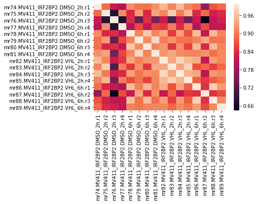

```python
%matplotlib inline
sns.heatmap(tccounts.corr(),
            xticklabels=tccounts.columns,
            yticklabels=tccounts.columns)
```

very strangely, we have in non euclidean space a structure that matches the labels we have. We hypotesized that noise might explain the difference in correlation that we see, however it would not explain that in euclidean space, things cluster still very well but differently.

As a matter of fact. real noise would not change the correlation at all. This noise has a structure. One thing can explain read count that, at low frequency transcripts, especially create a specific pattern: contamination

```python
tccounts.columns = tccount.colum
```

```python
todrop = ['mr78.MV411_IRF2BP2.DMSO_6h.r1', 'mr76.MV411_IRF2BP2.DMSO_2h.r3', 'mr80.MV411_IRF2BP2.DMSO_6h.r3', 'mr74.MV411_IRF2BP2.DMSO_2h.r1', 'mr84.MV411_IRF2BP2.VHL_2h.r3']
```

```python
tccounts = tccounts.drop(columns=[c for c in tccounts.columns if c in todrop])
readcounts = readcounts.drop(columns=[c for c in readcounts.columns if c in todrop])
```

```python
readcounts
```

| genes | mr75.MV411_IRF2BP2.DMSO_2h.r2 | mr77.MV411_IRF2BP2.DMSO_2h.r4 | mr79.MV411_IRF2BP2.DMSO_6h.r2 | mr81.MV411_IRF2BP2.DMSO_6h.r4 | mr82.MV411_IRF2BP2.VHL_2h.r1 | mr83.MV411_IRF2BP2.VHL_2h.r2 | mr85.MV411_IRF2BP2.VHL_2h.r4 | mr86.MV411_IRF2BP2.VHL_6h.r1 | mr87.MV411_IRF2BP2.VHL_6h.r2 | mr88.MV411_IRF2BP2.VHL_6h.r3 | mr89.MV411_IRF2BP2.VHL_6h.r4 |
| --- | --- | --- | --- | --- | --- | --- | --- | --- | --- | --- | --- |
| NFYA | 1472 | 1497 | 4425 | 3431 | 2046 | 2054 | 2151 | 2828 | 2603 | 2367 | 2198 |
| LAS1L | 1710 | 1888 | 2990 | 2539 | 2126 | 2819 | 2670 | 1485 | 2067 | 1479 | 1459 |
| ANKIB1 | 1004 | 909 | 2418 | 2069 | 1699 | 1498 | 1664 | 1760 | 1298 | 1550 | 1300 |
| CYP51A1 | 888 | 827 | 1078 | 839 | 1884 | 1372 | 1599 | 812 | 596 | 812 | 680 |
| LAP3 | 1643 | 1769 | 4193 | 3352 | 4004 | 3177 | 3303 | 2752 | 1224 | 2857 | 2464 |
| LASP1 | 13847 | 12054 | 25363 | 20811 | 13708 | 19010 | 19559 | 12493 | 17388 | 12164 | 12392 |
| SNX11 | 1782 | 1430 | 2986 | 2466 | 1357 | 2148 | 1501 | 1118 | 2020 | 1359 | 716 |
| M6PR | 7247 | 6673 | 11645 | 9648 | 10895 | 10474 | 12933 | 7740 | 7105 | 7670 | 7946 |
| CFLAR | 2451 | 2283 | 3718 | 3315 | 2843 | 3319 | 3075 | 1812 | 1815 | 1461 | 1476 |
| RBM5 | 658 | 671 | 1782 | 1601 | 799 | 1056 | 820 | 967 | 1184 | 741 | 750 |
| POLDIP2 | 1880 | 1797 | 3034 | 2562 | 1887 | 2632 | 2205 | 1538 | 2041 | 1383 | 1282 |
| PLXND1 | 2513 | 2620 | 4949 | 4162 | 2398 | 3945 | 3467 | 2175 | 3229 | 1935 | 1768 |
| AK2 | 18886 | 20671 | 30150 | 25986 | 30121 | 31265 | 35042 | 21097 | 19939 | 20836 | 18144 |
| CD38 | 2055 | 2279 | 2503 | 2212 | 3242 | 3097 | 2919 | 1040 | 958 | 1031 | 918 |
| RBM6 | 2148 | 2568 | 4632 | 4425 | 3780 | 4122 | 4042 | 3220 | 3121 | 2787 | 3458 |
| NDUFAB1 | 2748 | 7212 | 4735 | 3833 | 5842 | 4150 | 4433 | 3867 | 3066 | 4007 | 2835 |
| CDC27 | 4148 | 4120 | 7955 | 6837 | 7166 | 6041 | 6866 | 5904 | 4617 | 5560 | 4546 |
| HCCS | 336 | 272 | 700 | 526 | 508 | 458 | 510 | 461 | 323 | 371 | 340 |
| UPF1 | 3584 | 3368 | 6497 | 5621 | 3303 | 5683 | 5095 | 2637 | 4403 | 2544 | 2937 |
| DHX33 | 2429 | 4022 | 4015 | 3416 | 3244 | 3666 | 3193 | 2714 | 2728 | 2403 | 3053 |
| THSD7A | 742 | 794 | 2102 | 1732 | 1602 | 1146 | 1522 | 1758 | 902 | 1168 | 1122 |
| CIAPIN1 | 1958 | 2700 | 3692 | 3307 | 2596 | 2988 | 2949 | 2139 | 3109 | 2047 | 1749 |
| FAM214B | 684 | 504 | 1004 | 880 | 732 | 824 | 924 | 648 | 792 | 668 | 440 |
| KMT2E | 1739 | 1705 | 3413 | 2900 | 2952 | 2991 | 3456 | 2484 | 2009 | 1864 | 2856 |
| IBTK | 2490 | 2450 | 5206 | 4331 | 4300 | 3657 | 3862 | 4565 | 2729 | 3636 | 2793 |
| ZNF195 | 1694 | 2131 | 3456 | 2934 | 3945 | 2811 | 3534 | 3299 | 1479 | 3014 | 2271 |
| MYCBP2 | 390 | 691 | 915 | 885 | 911 | 669 | 669 | 726 | 448 | 701 | 407 |
| ITGAL | 11297 | 11339 | 18252 | 15621 | 11057 | 17786 | 15546 | 8010 | 11980 | 6602 | 7169 |
| ZFX | 1115 | 880 | 2296 | 1752 | 1825 | 1323 | 1464 | 1587 | 1111 | 1380 | 1059 |
| LAMP2 | 6397 | 5733 | 11067 | 9126 | 12607 | 9954 | 9485 | 7944 | 4747 | 7288 | 4857 |
| ... | ... | ... | ... | ... | ... | ... | ... | ... | ... | ... | ... |
| FAM47E-STBD1 | 745 | 692 | 1296 | 977 | 912 | 1165 | 1173 | 722 | 999 | 805 | 789 |
| ENSG00000272617 | 1686 | 2078 | 3012 | 2459 | 2351 | 2450 | 2824 | 1907 | 1907 | 1954 | 1522 |
| DCP1A | 788 | 688 | 1442 | 1283 | 911 | 1078 | 934 | 975 | 804 | 726 | 647 |
| SNURF | 1203 | 1146 | 1848 | 1485 | 1255 | 1770 | 2136 | 892 | 1143 | 839 | 1046 |
| CWC25 | 1495 | 1665 | 2963 | 2500 | 2358 | 2615 | 2733 | 2075 | 1870 | 1615 | 2127 |
| ZNHIT3 | 1518 | 2426 | 3095 | 2724 | 2834 | 2459 | 3319 | 2510 | 1798 | 2640 | 1726 |
| SOCS7 | 821 | 771 | 1483 | 1264 | 787 | 1132 | 892 | 826 | 911 | 572 | 558 |
| ZNF280B | 194 | 162 | 285 | 217 | 209 | 227 | 252 | 180 | 153 | 119 | 92 |
| PPP4R3B | 2913 | 3149 | 7968 | 6226 | 6417 | 4401 | 5543 | 6331 | 3461 | 5538 | 4974 |
| SYNRG | 713 | 822 | 1715 | 1709 | 1177 | 1122 | 1036 | 1176 | 1197 | 728 | 923 |
| PRAG1 | 190 | 222 | 410 | 318 | 172 | 282 | 214 | 216 | 146 | 156 | 180 |
| AATF | 1729 | 2153 | 3397 | 2859 | 2804 | 2915 | 3859 | 2164 | 2161 | 1923 | 3159 |
| UHRF1 | 2228 | 1977 | 3983 | 3331 | 3514 | 3218 | 3319 | 2518 | 1724 | 2221 | 2155 |
| TADA2A | 992 | 1450 | 2475 | 2066 | 1723 | 1517 | 1789 | 1792 | 1420 | 1413 | 1302 |
| PIP4K2B | 1908 | 1836 | 4116 | 3428 | 2061 | 2619 | 2226 | 2183 | 2632 | 1909 | 1372 |
| PCDHGB5 | 1232 | 1182 | 2071 | 1747 | 1148 | 1862 | 1954 | 790 | 1047 | 620 | 672 |
| RAB7B | 2606 | 2551 | 7429 | 6266 | 3599 | 4664 | 5777 | 3286 | 5232 | 3673 | 4300 |
| PSMB3 | 2677 | 4981 | 4161 | 3508 | 4884 | 4451 | 5856 | 3172 | 2913 | 3455 | 3401 |
| SENP3-EIF4A1 | 11621 | 12654 | 18570 | 16144 | 14706 | 18000 | 17241 | 11329 | 13398 | 10447 | 8555 |
| DDX52 | 2958 | 3324 | 5998 | 5285 | 5028 | 4228 | 4579 | 4434 | 3483 | 3620 | 3395 |
| ZNF8 | 694 | 554 | 979 | 888 | 706 | 941 | 810 | 605 | 618 | 512 | 362 |
| MYO19 | 1458 | 1849 | 3211 | 2827 | 1924 | 2440 | 2288 | 1631 | 1889 | 1414 | 1105 |
| GGNBP2 | 252 | 243 | 548 | 404 | 484 | 426 | 409 | 309 | 221 | 314 | 227 |
| ACACA | 2077 | 2098 | 3626 | 3204 | 2591 | 3093 | 3121 | 2380 | 3027 | 1885 | 1940 |
| MRPL45 | 1426 | 1834 | 2936 | 2490 | 2614 | 2144 | 2370 | 2084 | 1810 | 1890 | 1460 |
| ENSG00000280893 | 992 | 1140 | 2003 | 1683 | 1394 | 1483 | 2006 | 1147 | 1307 | 1130 | 1256 |
| ENSG00000280987 | 10777 | 7379 | 20439 | 16645 | 28231 | 15843 | 19540 | 19652 | 6260 | 18860 | 8104 |
| ENSG00000282827 | 620 | 776 | 1350 | 1078 | 824 | 985 | 970 | 838 | 912 | 675 | 833 |
| ENSG00000283228 | 1198 | 1053 | 2139 | 1841 | 3148 | 2037 | 2678 | 1997 | 1055 | 1842 | 1509 |
| ENSG00000283515 | 2335 | 4649 | 3639 | 3300 | 3607 | 4106 | 4933 | 2487 | 2554 | 2188 | 2690 |

4981 rows × 11 columns

```python
scatter(UMAP(n_neighbors=2,min_dist=0.3).fit_transform(tccounts.values.T),labels=tccounts.columns, radi=2)
```

[interactive chart not shown]

[figure not shown]

```python
%matplotlib inline
sort = [0,8,10,4,6,14,12,1,11,9,5,7,13,3,15,2]
sns.heatmap(tccounts[tccounts.columns[sort]].corr(),
            xticklabels=tccounts.columns[sort].values,
            yticklabels=tccounts.columns[sort].values)
```

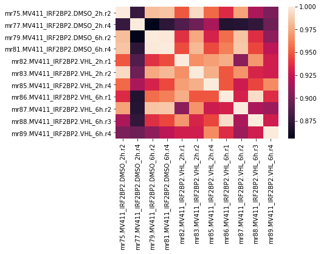

```python
%matplotlib inline
sns.heatmap(readcounts.corr(),
            xticklabels=readcounts.columns,
            yticklabels=readcounts.columns)
```

[figure not shown]

```python
%matplotlib inline
sort = [0,8,10,4,12,6,14,1,9,5,13,7,11,15,3,2]
sns.heatmap(readcounts[readcounts.columns[sort]].corr(),
            xticklabels=readcounts.columns.values[sort],
            yticklabels=readcounts.columns.values[sort])
```

read the paper for MV411 QC steps.

## Getting the Core TF information

```python
ctf=pd.read_csv('../data/CTF.csv',header=None)[0].values.tolist()
ctf
```

```
['MYC',
 'MYB',
 'SPI1',
 'RUNX1',
 'GSE1',
 'IRF2BP2',
 'FLI1',
 'ELF2',
 'ZEB2',
 'IKAROS',
 'GFI1',
 'LMO2',
 'CEBPA',
 'MEF2D',
 'MEF2C',
 'IRF8',
 'MEIS1',
 'RUNX2',
 'ETV6',
 'LDB1',
 'RUNX2',
 'SP1',
 'ZMYND8']
```

```python
set(ctf) & set(tccounts.index)
```

```
{'CEBPA',
 'ELF2',
 'ETV6',
 'FLI1',
 'GFI1',
 'GSE1',
 'IRF2BP2',
 'IRF8',
 'LMO2',
 'MEF2C',
 'MEF2D',
 'MEIS1',
 'MYB',
 'MYC',
 'RUNX1',
 'RUNX2',
 'SP1',
 'SPI1',
 'ZEB2',
 'ZMYND8'}
```

```python
ctfpos = [val for val in tccounts.index if val in ctf]
notctfpos = [val for val in tccounts.index if val not in ctf]
```

```python
ctfpos.extend(['EGR1','SERTAD1'])
```

# Let's look at how they change accross time

## DESEQ ANALYSIS

```python
readcounts["genes"] = readcounts.index
readcounts = readcounts.reset_index(drop=True)
tccounts["genes"] = tccounts.index
tccounts = tccounts.reset_index(drop=True)
```

```python
tccounts.iloc[140]
```

```
mr75.MV411_IRF2BP2.DMSO_2h.r2      175
mr77.MV411_IRF2BP2.DMSO_2h.r4      149
mr79.MV411_IRF2BP2.DMSO_6h.r2      191
mr81.MV411_IRF2BP2.DMSO_6h.r4      189
mr82.MV411_IRF2BP2.VHL_2h.r1       236
mr83.MV411_IRF2BP2.VHL_2h.r2       258
mr85.MV411_IRF2BP2.VHL_2h.r4       220
mr86.MV411_IRF2BP2.VHL_6h.r1        90
mr87.MV411_IRF2BP2.VHL_6h.r2       115
mr88.MV411_IRF2BP2.VHL_6h.r3        76
mr89.MV411_IRF2BP2.VHL_6h.r4       113
genes                            KPNA6
Name: 140, dtype: object
```

```python
tccounts.columns
```

```
Index(['mr75.MV411_IRF2BP2.DMSO_2h.r2', 'mr77.MV411_IRF2BP2.DMSO_2h.r4',
       'mr79.MV411_IRF2BP2.DMSO_6h.r2', 'mr81.MV411_IRF2BP2.DMSO_6h.r4',
       'mr82.MV411_IRF2BP2.VHL_2h.r1', 'mr83.MV411_IRF2BP2.VHL_2h.r2',
       'mr85.MV411_IRF2BP2.VHL_2h.r4', 'mr86.MV411_IRF2BP2.VHL_6h.r1',
       'mr87.MV411_IRF2BP2.VHL_6h.r2', 'mr88.MV411_IRF2BP2.VHL_6h.r3',
       'mr89.MV411_IRF2BP2.VHL_6h.r4', 'genes'],
      dtype='object')
```

```python
design_2 = pd.DataFrame(index=[i.replace('-','.') for i in tccounts.columns.values[:-1]],
                      columns=['DMSO','VHL'],
                      data=np.array([[1,1,0,0,0,0,0,0,0,0,0],
                                     [0,0,0,0,1,1,1,0,0,0,0]],dtype=bool).T)
```

```python
design_6 = pd.DataFrame(index=[i.replace('-','.') for i in tccounts.columns.values[:-1]],
                      columns=['DMSO','VHL'],
                      data=np.array([[0,0,1,1,0,0,0,0,0,0,0],
                                     [0,0,0,0,0,0,0,1,1,1,1]],dtype=bool).T)
```

### Differential gene expression analysis, PCA and GO-term enrichment

For gene-level analysis, raw reads mapped to different UTR annotations of the same gene were summed up by Entrez Gene ID. Pilot studies of K562 cells with kinase inhibitors were performed as single experiments.

Analysis of differential gene expression was restricted to genes with ≥ 10 reads in at least one condition for 50bp sequencing runs (flavopiridol and DMSO) or ≥ 20 reads in at least one condition for 100bp sequencing runs (mk2206, trametinib, nilotinib, trametinib + mk2206 and DMSO). For estimating differential expression, a pseudo-count of 1 raw read was added to all genes.

#### All other SLAM-seq experiments were performed in triplicates and analyzed as follows.

Differential gene expression calling was performed on raw read counts with ≥ 2 T>C conversions using DESeq2 (version 1.14.1) with default settings, and with size factors estimated on corresponding total mRNA reads for global normalization.

Downstream analysis was restricted to genes passing all internal filters for FDR estimation by DESeq2. Principal component analysis was performed after variance stabilizing transformation on the 500 most variable genes across all conditions of a given experiment. GO-term enrichment analysis was performed on genes significantly and strongly downregulated (FDR ≤ 0.1, log2FC ≤ -1) in SLAM-seq upon IAA-treatment in K562MYC-AID + Tir1 by the PANTHER Overrepresentation Test (Fisher's Exact with FDR multiple test correction, release 20171205, http://pantherdb.org) on GO Ontology database Released 2017-12-27.

```python
design
```

```
---------------------------------------------------------------------------
NameError                                 Traceback (most recent call last)
<ipython-input-97-fadf3aa09cfd> in <module>
----> 1 design

NameError: name 'design' is not defined
```

```python
tccounts.columns = [i.replace('-','.') for i in tccounts.columns]
```

```python
tccounts[tccounts.genes=='MYC']
```

[output not shown]

```python
deseq_2 = pyDESeq2.pyDESeq2(count_matrix=tccounts[tccounts.columns[np.array([1,1,0,0,1,1,1,0,0,0,0,1],np.bool)]],
                         design_matrix=design_2[np.array([1,1,0,0,1,1,1,0,0,0,0],np.bool)],
                         design_formula="~DMSO - VHL",
                         gene_column="genes")
```

```
3.0.4
```

```python
deseq_6 = pyDESeq2.pyDESeq2(count_matrix=tccounts[tccounts.columns[np.array([0,0,1,1,0,0,0,1,1,1,1,1],np.bool)]],
                         design_matrix=design_6[np.array([0,0,1,1,0,0,0,1,1,1,1],np.bool)],
                         design_formula="~DMSO - VHL",
                         gene_column="genes")
```

```
3.0.4
```

```python
np.exp(np.mean(np.log(readcounts[readcounts.columns[np.array(
    [1,0,0,0,0,0,0,0,0,0,0,0,0,1,0,0,0],np.bool)]].values+1), 1))
```

[output not shown]

```python
deseq_2.run_estimate_size_factors(geoMeans = np.exp(np.mean(np.log(
    readcounts[readcounts.columns[
        np.array([1,1,0,0,0,0,0,0,0,0,0,0],np.bool)]].values+1), 1)))
```

```python
deseq_6.run_estimate_size_factors(geoMeans = np.exp(np.mean(np.log(
    readcounts[readcounts.columns[
        np.array([0,0,1,1,0,0,0,0,0,0,0,0],np.bool)]].values+1), 1)))
```

```python
deseq_2.run_deseq()
deseq_6.run_deseq()
```

[output not shown]

```python
deseq_2.get_deseq_result()
deseq_6.get_deseq_result()
```

```python
res2 = deseq_2.deseq_result
res6 = deseq_6.deseq_result
```

```python
res2.pvalue = np.nan_to_num(np.array(res2.pvalue), 1)
res2.log2FoldChange = np.nan_to_num(np.array(res2.log2FoldChange), 0)
res6.pvalue = np.nan_to_num(np.array(res6.pvalue), 1)
res6.log2FoldChange = np.nan_to_num(np.array(res6.log2FoldChange), 0)
```

```python
JQ1res[JQ1res.genes=='MYC']
```

[output not shown]

```python
JQ1res.to_csv("data/jq1.mv411.csv")
```

```python
JQ1res.log2FoldChange = -JQ1res.log2FoldChange
```

```python
res2["gene_id"] = res2.genes
res6["gene_id"] = res6.genes
```

```python
JQ1res[JQ1res.gene_id=='HNRNPA1']
```

[output not shown]

```python
show(volcano(res6,tohighlight=ctf, searchbox=True))
```

[interactive chart not shown]

```python
show(volcano(res2,tohighlight=ctf, searchbox=True))
```

[interactive chart not shown]